# 3. Estadio crónico

Max Orozco Carstensen

2023-10-11

# Estadio crónico

Las siguientes ecuaciones describen un modelo por compartimentos de una enfermedad infecciosa con un estadio crónico.
$$\dot S = \nu - \beta S(I + qC) - \mu S + \rho
R$$
$$\dot C = \beta S(I + qC) - (\eta
+\gamma +\mu)C$$
$$\dot I = \eta C -
(\alpha +\mu)I$$
$$\dot R = \alpha I +
\gamma C - (\mu + \rho)R$$

1. **Dibuja el esquema por compartimentos que representa este conjunto de ecuaciones.**

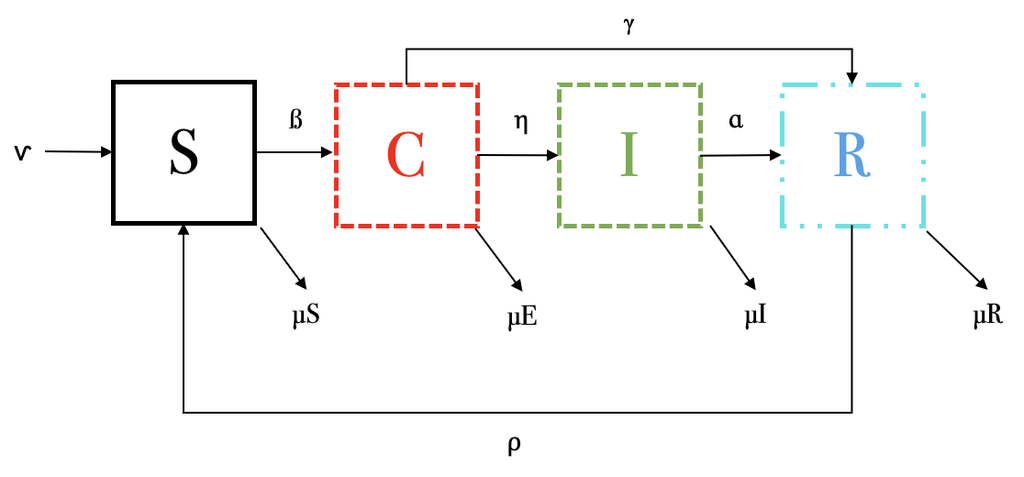

2. **Explica el significado de cada ecuación: es decir, explica el significado de cada término y cada parámetro. ¿Existen parámetros que están acotados?, si es así, indica el intervalo en donde pueden variar.**
- $\nu$: Tasa de nacimientos o individuos que entran al sistema.
- $\beta$: Tasa de interacción entre susceptibles e infectados.
- $q$: Tasa de interacción entre susceptibles y crónicos.
- $\rho$: Tasa en la que individuos que vuelven a ser susceptibles, después de recuperarse.
- $\mu$: Tasa de muertes o individuos que salen del sistema.
- $\eta$: Tasa en la que los individuos pasan de ser crónicos a sólo infectados.
- $\gamma$: Tasa en la que los crónicos se recuperan.
- $\alpha$: Tasa en la que los infectados se recuperan.

Todas las tasas son acotadas, debido a que es $1/tiempo$.

*Susceptibles:*

Favorece:

- $\nu$: Individuos que nacen o entran al sistema.
- $\rho R$ Individuos que vuelven a ser susceptibles después de recuperarse.

Afecta:

- $\beta SI$: Interacción entre susceptibles e infectados.
- $\beta S q C$: Interacción entre susceptibles y crónicos.
- $\mu S$: Individuos susceptibles que mueren o salen del sistema.

*Crónicos:*

Favorece:

- $\beta SI$: Interacción entre susceptibles e infectados.
- $\beta S q C$: Interacción entre susceptibles y crónicos.

Afecta:

- $\eta C$: Individuos que pasan a ser infectados o crónicos.
- $\gamma C$: Individuos crónicos que se recuperan.
- $\mu C$ Individuos expuestos que mueren o salen del sistema.

*Infectados:*

Favorece:

- $p \eta C$: Individuos crónicos que pasan a infectados.

Afecta:

- $\alpha I$: Individuos infectados que se recuperan.
- $\mu I$: Individuos infectados que mueren o salen del sistema.

*Recuperados:*

Favorece:

- $\alpha I$: Individuos infectados que se recuperan.
- $\gamma A$: Individuos crónicos que se recuperan.

Afecta:

- $\rho R$: Individuos que vuelven a ser susceptibles, después de recuperarse.
- $\mu R$: Individuos recuperados que mueren o salen del sistema.
3. **¿Bajo qué condiciones la población se conservaría?**

La población se conservaría si la suma de las tasas de muerte es igual a la tasa de nacimientos.
$$\nu = (\mu
S + \mu C + \mu I + \mu R)$$

4. **Encuentra, si existe, el punto de equilibrio *free-disease***

Debido a que el modelo *free-disease* hace referencia a que no hay individuos infectados, con esa misma premisa, no puede haber individuos crónicos, ni recuperados, únicamente susceptibles. Si se igualan esas condiciones a 0, queda:

$$\dot S = \nu - \beta S (0 +q0) - \mu S +
\rho 0 = \nu - \mu S = S = \nu / \mu$$
$$\dot C = \beta S (0 + q0) - (\eta + \gamma +
\mu)0 = 0$$
$$\dot I = \eta 0 -
(\alpha + \mu)0 = 0$$
$$\dot R =
\alpha 0 + \gamma 0 - (\mu + \rho) 0 = 0$$

Por lo tanto, el punto de equilibrio *free-disease* sería: $(S, C, I, R) = (\nu / \mu, 0, 0, 0)$

5. **¿Qué tipo de enfermedad puede estar describiendo? Justifica tu respuesta.**

Podría ser la tuberculosis, por el estadio crónico infeccioso, en donde la bacteria queda en estado latente. Además, se tiene el paso de crónico a infectado; sin embargo, yo añadiría el paso de susceptible a infectado, para este ejemplo.

6. **Selecciona un conjunto de parámetros adecuados y resuelve numéricamente el sistema de ecuaciones diferenciales. Asegúrate que tu solución alcance un punto de equilibrio.Discute tu resultado.**

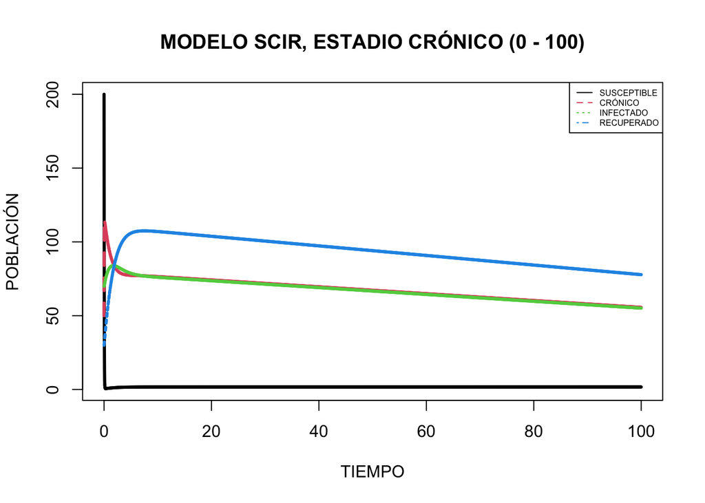

```r
library (deSolve)

SCIR <- function (time, state, parameters) {
  with (as.list (c (state, parameters)), {
    dS <- nu - beta * S * I - beta * S * q * C + rho * R - muS
    dC <- beta * S * I - beta * S * q * C - eta * C + gamma * C - muC
    dI <- eta * C - alpha * I - muI
    dR <- alpha * I + gamma * C - rho * R - muR
    list (c (dS, dC, dI, dR))
  })
}

parameters <- c (nu = 1, beta = 0.3, rho = 0.5, q = 0.4, eta = 0.5, gamma = 0.2, alpha = 0.5, muS = 0.2, muC = 0.4, muI = 0.5, muR = 0.1)
initial_conditions <- c (S = 200, C = 50, I = 70, R = 30)
time <- seq (0, 100, by = 0.001)
out <- ode (initial_conditions, time, SCIR, parameters)

matplot (out [ , 1], out [ , 2 : 5], type = "l", xlab = "TIEMPO", ylab = "POBLACIÓN", main = "MODELO SCIR, ESTADIO CRÓNICO (0 - 100)", lwd = 3)
legend ("topright", c ("SUSCEPTIBLE", "CRÓNICO", "INFECTADO", "RECUPERADO"), col = 1 : 4, lty = 1 : 5, cex = 0.5)
```

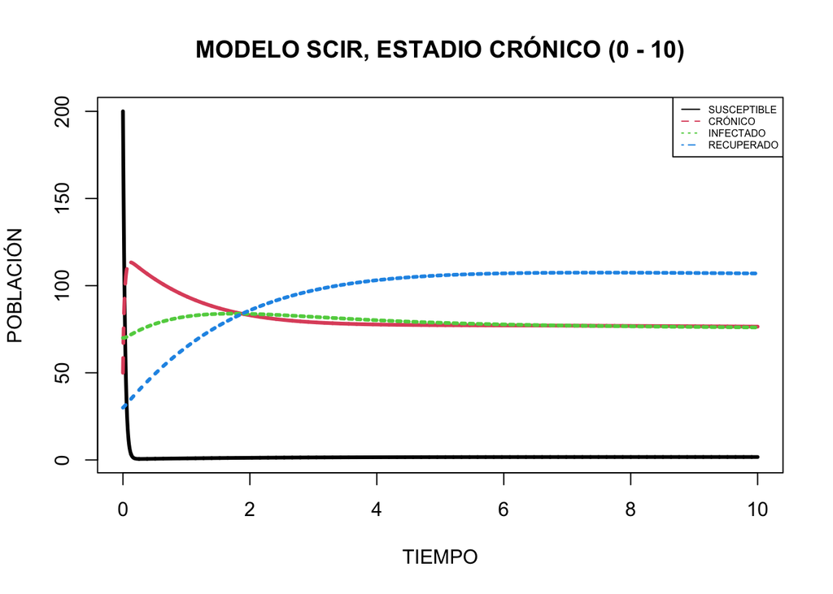

```r
parameters <- c (nu = 1, beta = 0.3, rho = 0.5, q = 0.4, eta = 0.5, gamma = 0.2, alpha = 0.5, muS = 0.2, muC = 0.4, muI = 0.5, muR = 0.1)
initial_conditions <- c (S = 200, C = 50, I = 70, R = 30)
time <- seq (0, 10, by = 0.001)
out <- ode (initial_conditions, time, SCIR, parameters)

matplot (out [ , 1], out [ , 2 : 5], type = "l", xlab = "TIEMPO", ylab = "POBLACIÓN", main = "MODELO SCIR, ESTADIO CRÓNICO (0 - 10)", lwd = 3)
legend ("topright", c ("SUSCEPTIBLE", "CRÓNICO", "INFECTADO", "RECUPERADO"), col = 1 : 4, lty = 1 : 5, cex = 0.5)
```